# Medical_Cost_code_04

Medical_Cost_code_04 Nam, Yeong-jae 2023-12-09

필요패키지: `Hmisc`, `corrplot`, `ggplot2`, `tidyverse`, `patchwork`, `WVPlots`, `randomForest``

## 0. 설명 및 패키지 준비

다른 환자들의 치료비에 대한 데이터를 분석할 것이다. 치료비는 다양한 Factor에 의해 영향을 받는다. 그러나 환자들의 건강에 대해서 결론을 내리고 회귀분석을 실행하는데 보여지는 변수들의 수치가 아닌 도움이 되는 다른 정보가 있다. 데이터를 살펴보자.

```r
library(Hmisc)
```

```r
library(corrplot)
library(ggplot2)
library(tidyverse)
library(patchwork)
library(WVPlots)
library(randomForest)
```

## 1. 데이터 확인하기.

데이터를 `colnames()`로 확인해보면, 총 7개의 변수(나이, 성별, BMI, 자식의 수, 흡연여부, 지역, 보험비용)가 있는 것을 확인할 수 있다.

```r
insurance = read.csv(".\\data\\medical_cost.csv")

# 변수 확인하기.
colnames(insurance)
```

```
## [1] "age"      "sex"      "bmi"      "children" "smoker"   "region"   "charges"
```

```r
# 관측값의 수 확인하기
nrow(insurance)
```

```
## [1] 1338
```

```r
# 결측치 확인(using Hmisc package).
describe(insurance)
```

```
## insurance
##
##  7  Variables      1338  Observations
## --------------------------------------------------------------------------------
## age
##        n  missing distinct     Info     Mean      Gmd      .05      .10
##     1338        0       47    0.999    39.21    16.21       18       19
##      .25      .50      .75      .90      .95
##       27       39       51       59       62
##
## lowest : 18 19 20 21 22, highest: 60 61 62 63 64
## --------------------------------------------------------------------------------
## sex
##        n  missing distinct
##     1338        0        2
##
## Value      female   male
## Frequency     662    676
## Proportion  0.495  0.505
## --------------------------------------------------------------------------------
## bmi
##        n  missing distinct     Info     Mean      Gmd      .05      .10
##     1338        0      548        1    30.66    6.893    21.26    22.99
##      .25      .50      .75      .90      .95
##    26.30    30.40    34.69    38.62    41.11
##
## lowest : 15.96  16.815 17.195 17.29  17.385, highest: 48.07  49.06  50.38  52.58  53.13
## --------------------------------------------------------------------------------
## children
##        n  missing distinct     Info     Mean      Gmd
##     1338        0        6    0.899    1.095    1.275
##
## Value          0     1     2     3     4     5
## Frequency    574   324   240   157    25    18
## Proportion 0.429 0.242 0.179 0.117 0.019 0.013
##
## For the frequency table, variable is rounded to the nearest 0
## --------------------------------------------------------------------------------
## smoker
##        n  missing distinct
```

[output cut: 8 more lines]

```
##     1338        0        4
##
## Value      northeast northwest southeast southwest
## Frequency        324       325       364       325
## Proportion     0.242     0.243     0.272     0.243
## --------------------------------------------------------------------------------
## charges
##        n  missing distinct     Info     Mean      Gmd      .05      .10
##     1338        0     1337        1    13270    12301     1758     2347
##      .25      .50      .75      .90      .95
##     4740     9382    16640    34832    41182
##
## lowest : 1121.87 1131.51 1135.94 1136.4  1137.01
## highest: 55135.4 58571.1 60021.4 62592.9 63770.4
## --------------------------------------------------------------------------------
```

```r
# 결측치 확인(base function)
colSums(is.na(insurance))
```

```
##      age      sex      bmi children   smoker   region  charges
##        0        0        0        0        0        0        0
```

```r
any(is.na(insurance)) # 전체 데이터에 결측치가 있는지 확인
```

```
## [1] FALSE
```

결측치가 없다! 그러니 마음편히 데이터를 만지작 거릴 수 있다. 일단 보험비용과 변수들 간의 상관관계를 확인하고 싶다. 그러기 위해서 character 자료를 범주형 자료로 변환하겠다.

## 2. 데이터 전처리하기

성별, 흡연 여부, 지역 변수는 Factor형으로 변환해야 한다.

```r
insurance$sex = as.factor(insurance$sex)

insurance$smoker = as.factor(insurance$smoker)

insurance$region = as.factor(insurance$region)
```

## 3. 상관성 확인하기.

상관성을 확인하고 싶다. 그러나 범주형 변수와 다른 수치형 변수 간의 상관성은 확인하기 껄끄럽다.

```r
insurance_mat = insurance

insurance_mat$sex = as.numeric(insurance_mat$sex)

insurance_mat$smoker = as.numeric(insurance_mat$smoker)

insurance_mat$region = as.numeric(insurance_mat$region)

insurance_mat = as.matrix(insurance_mat)


# 비용과 나머지 변수들 간의 상관계수
cor(insurance_mat[,7], insurance_mat[,-7])
```

```
##            age        sex      bmi   children    smoker       region
## [1,] 0.2990082 0.05729206 0.198341 0.06799823 0.7872514 -0.006208235
```

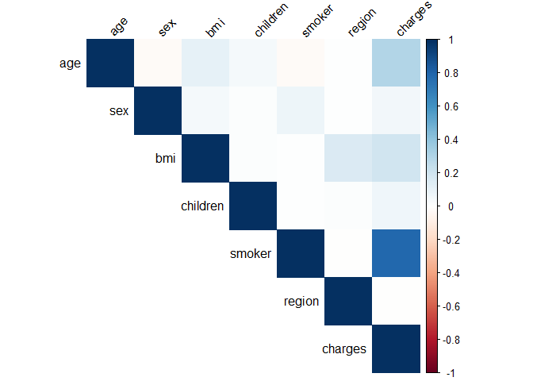

```r
cor_mat = cor(insurance_mat)

# 상관계수 행렬을 히트맵으로 시각화
corrplot(cor_mat, method='color', type='upper', tl.col='black', tl.srt=45)
```

비용과 흡연과의 관계가 가장 상관성이 높다! 그런데 순서형 변수가 아니라 명목형 변수라 의미가 있는지는 잘 모르겠다. 흡연 외에도 BMI와도 높은 상관성을 보일 줄 알았는데 그렇지 않았다. 아무튼 흡연과 비용간의 상관성에 대해서 더욱더 파고들어보자.

## 4. 보험비용의 분포

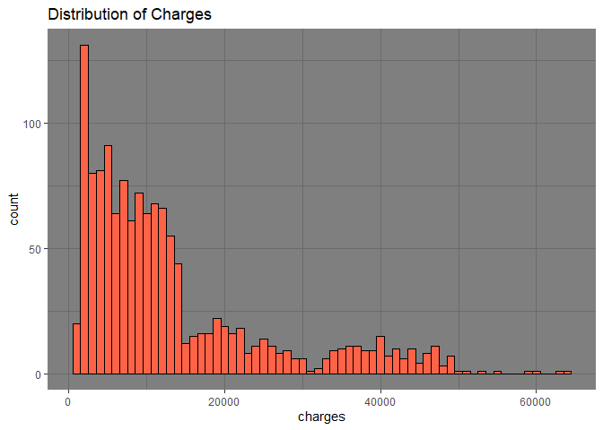

```r
ggplot(insurance, aes(charges)) + geom_histogram(fill="tomato", color='black', binwidth = 1000) + labs(title="Distribution of Charges") + theme_dark()
```

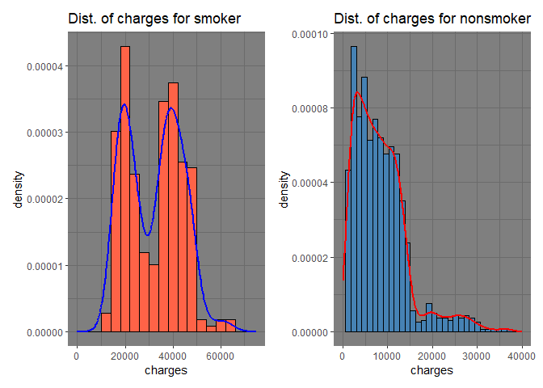

```r
# 흡연자와 비흡현자에 대한 자료를  분리
ins_smoke = insurance %>% filter(smoker=="yes")

ins_non_smoke = insurance %>% filter(smoker=="no")

# 시각화

left = ggplot(ins_smoke, aes(charges)) +
  geom_histogram(aes(y=..density..),color='black', fill="tomato", binwidth=4000) +
  geom_density(size=0.8, color='blue') +
  ggtitle("Dist. of charges for smoker") +
  xlim(10,75000) +
  scale_y_continuous(labels = scales::number_format(accuracy = 0.00001)) +
  theme_dark()


right = ggplot(ins_non_smoke, aes(x=charges)) +
  geom_histogram(aes(y=..density..), color='black', fill="steelblue", binwidth=1200) +
  geom_density(size=0.8, color='red') +
  ggtitle("Dist. of charges for nonsmoker") +
  xlim(10,40000) +
  scale_y_continuous(labels = scales::number_format(accuracy = 0.00002)) +
  theme_dark()

(left + right)
```

흡연자와 비흡현자로 구분된 보험비용의 히스토그램을 보면 비흡현자는 낮은 청구비용에 많이 분포되어 있고, 비교적 흡연자들이 높은 보험비용이 청구된다. 두 집단의 크기는 차이가 꽤 나는 편이지만, 일단 분포를 보면 그렇다.

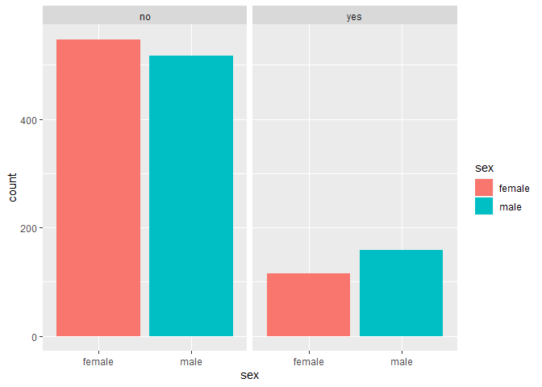

```r
ggplot(insurance, aes(sex, fill=sex)) + geom_bar(stat="count") + facet_grid(~smoker)
```

확실히 비흡연자가 더 많다. 남성 흡연자가 여성 흡연자보다 많다는 것 또한 알 수 있다. 이를 통해 흡연에 따라 남성의 치료비용이 더 높다는 것을 유추해 볼 수 있다. 다양하게 시각화를 진행해보겠다.

### 4-1. 성별에 따른 시각화

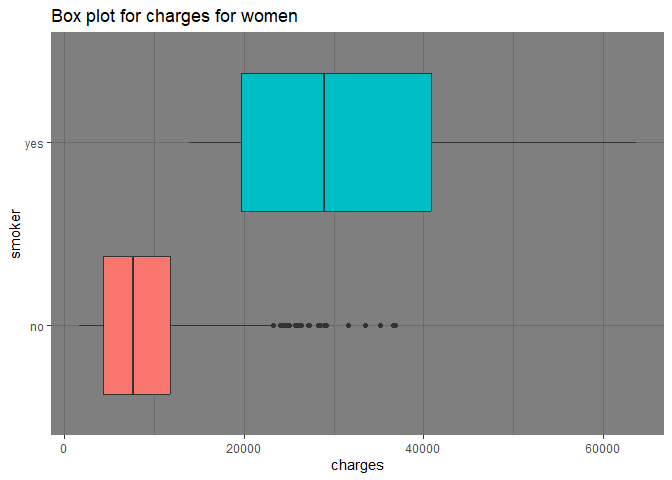

```r
# 여성의 흡연에 따른 치료비용에 대한 Boxplot
insurance %>%
  filter(sex=="female") %>%
  ggplot(aes(smoker, charges, fill = smoker)) +
  geom_boxplot() +
  ggtitle("Box plot for charges for women") +
  coord_flip() +
  theme_dark() +
  theme(legend.position="none")
```

[figure not shown]

```r
# 남성의 흡연에 따른 보험청구 비용에 대한 Boxplot

insurance %>%
  filter(sex=="male") %>%
  ggplot(aes(smoker, charges, fill = smoker)) +
  geom_boxplot() +
  ggtitle("Box plot for charges for women") +
  coord_flip() +
  theme_dark() +
  theme(legend.position="none")
```

### 4-2. 나이에 따른 시각화

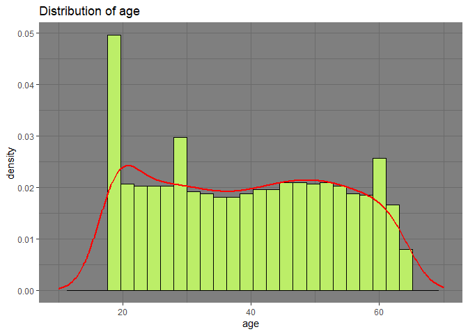

```r
ggplot(insurance, aes(age)) +
  geom_histogram(aes(y=..density..), fill="darkolivegreen2",color="black") +
  geom_density(size=0.8,color="red") +
  xlim(10,70) +
  labs(title="Distribution of age") +
  theme_dark()
```

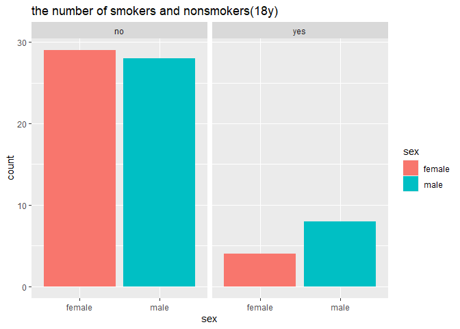

```r
insurance %>%
  filter(age == 18) %>%
  ggplot(aes(sex, fill=sex)) +
  ggtitle("the number of smokers and nonsmokers(18y)") +
  geom_bar(stat="count") +
  facet_grid(~smoker)
```

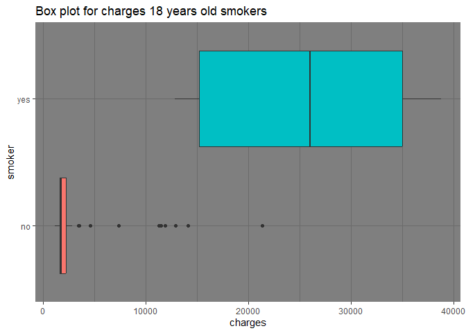

```r
insurance %>%
  filter(age==18) %>%
  ggplot(aes(smoker, charges, fill = smoker)) +
  geom_boxplot() +
  ggtitle("Box plot for charges 18 years old smokers") +
  coord_flip() +
  theme_dark() +
  theme(legend.position="none")
```

흡연하는 18세에서 치료비용 분포가 극적으로 구별되는 것이 확인된다. 이상치들이 보이는데, 이는 아마도 질병을 겪고 있거나, 사고를 당한 경우이지 안을 까 싶다. 이제 비용이 나이에 따라서 얼마나 달라지는 지 확인해 보겠다.

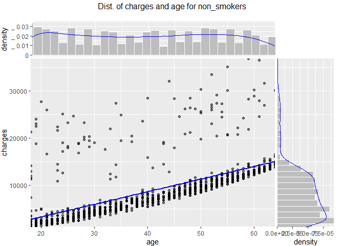

```r
age_charge= data.frame(
  age=ins_non_smoke$age,
  charges=ins_non_smoke$charges,
  stringsAsFactors = F
)

age_charge$absCharges=abs(age_charge$charges)
age_charge$posCharges= age_charge$charges > 0

# ScatterHist(data.frame, "xname", "yname", ...)
ScatterHist(age_charge, "age", "charges", title="Dist. of charges and age for non_smokers")
```

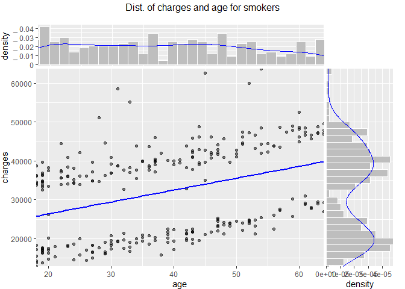

```r
age_charge= data.frame(
  age=ins_smoke$age,
  charges=ins_smoke$charges,
  stringsAsFactors = F
)

age_charge$absCharges=abs(age_charge$charges)
age_charge$posCharges= age_charge$charges > 0

# ScatterHist(data.frame, "xname", "yname", ...)
ScatterHist(age_charge, "age", "charges", title="Dist. of charges and age for smokers")
```

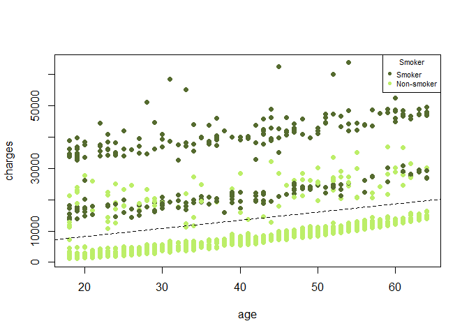

```r
plot(insurance$age, insurance$charges, col = ifelse(insurance$smoker == "yes", "darkolivegreen", "darkolivegreen2"), pch=16, xlab="age", ylab="charges")
abline(lm(insurance$charges~insurance$age, insurance), col="black", lty=2)
legend("topright",legend=c("Smoker", "Non-smoker"), col=c("darkolivegreen", "darkolivegreen2"), pch=16, cex=0.7, title="Smoker")
```

### 4-3. BMI에 따른 시각화

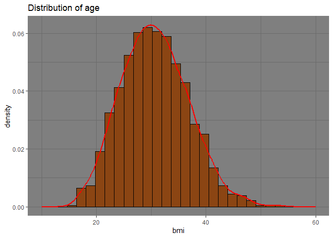

```r
ggplot(insurance, aes(bmi)) +
  geom_histogram(aes(y=..density..), fill="chocolate4",color="black") +
  geom_density(size=0.8,color="red") +
  xlim(10, 60) +
  labs(title="Distribution of age") +
  theme_dark()
```

분포의 평균이 거의 30에 가까워 보인다. 30을 기준으로 나눠서 확인하겠다.

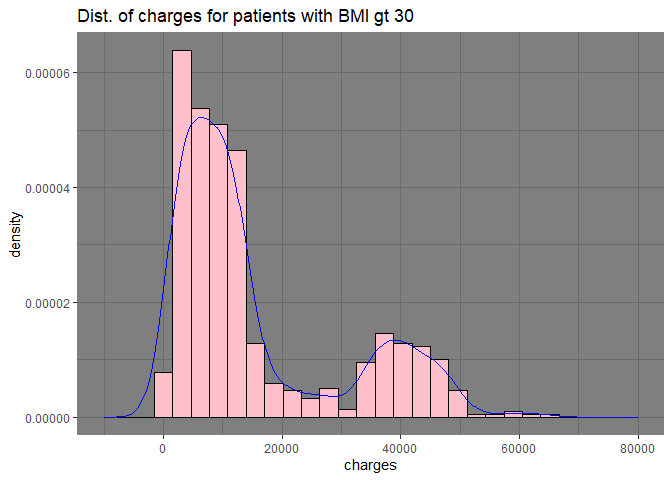

```r
# bmi가 30이상인 경우의 비용
insurance %>%
  filter(bmi >= 30) %>%
  ggplot(aes(charges)) +
  geom_histogram(aes(y=..density..), fill='pink', color='black') +
  geom_density(color="blue") +
  ggtitle("Dist. of charges for patients with BMI gt 30") +
  xlim(-10000,80000) +
  theme_dark() +
  scale_y_continuous(labels = scales::number_format(accuracy = 0.00001))
```

[figure not shown]

```r
# bmi가 30미만인 경우의 비용
insurance %>%
  filter(bmi < 30) %>%
  ggplot(aes(charges)) +
  geom_histogram(aes(y=..density..), fill='ghostwhite', color='black') +
  geom_density(color="blue") +
  ggtitle("Dist. of charges for patients with BMI gt 30") +
  xlim(-5000,45000) +
  theme_dark() +
  scale_y_continuous(labels = scales::number_format(accuracy = 0.00001))
```

BMI가 30이상인 사람들이 치료비용을 더 많이 지불하는 것이 확인된다.

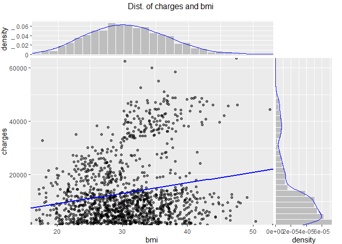

```r
bmi_charge= data.frame(
  bmi=insurance$bmi,
  charges=insurance$charges,
  stringsAsFactors = F
)

bmi_charge$absCharges=abs(bmi_charge$charges)
bmi_charge$posCharges= bmi_charge$charges > 0

# ScatterHist(data.frame, "xname", "yname", ...)
ScatterHist(bmi_charge, "bmi", "charges", title="Dist. of charges and bmi")
```

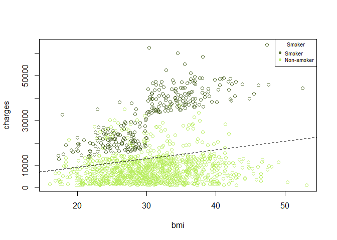

```r
plot(insurance$bmi, insurance$charges, col = ifelse(insurance$smoker == "yes", "darkolivegreen", "darkolivegreen2"), xlab="bmi", ylab="charges")


abline(lm(insurance$charges~insurance$bmi, insurance), col="black", lty=2)

legend("topright",legend=c("Smoker", "Non-smoker"), col=c("darkolivegreen", "darkolivegreen2"), pch=16, cex=0.7, title="Smoker")
```

### 4-4. 아이들

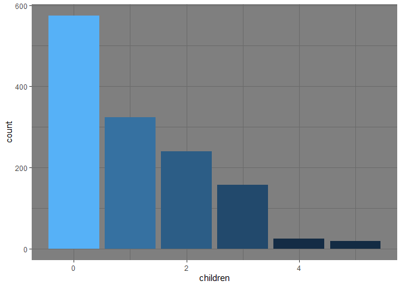

```r
ggplot(insurance, aes(children)) + geom_bar(aes(fill=..count..)) + theme_dark() + theme(legend.position="none")
```

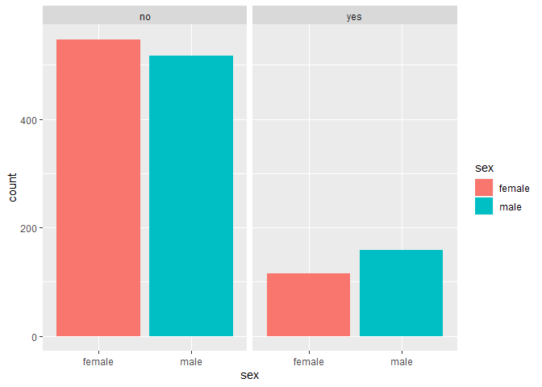

```r
ggplot(insurance, aes(sex, fill=sex)) + geom_bar() + facet_grid(~smoker)
```

### 5. linear Regression

예측을 해보자.

```r
# 훈련자료와 시험자료를 분리
set.seed(123)
train_data = round(0.7 * nrow(insurance))
train_indices = sample(1:nrow(insurance), train_data)
ins_train = insurance[train_indices,]
ins_test = insurance[-train_indices,]
```

```r
# 선형회귀
model = lm(charges ~ ., data=ins_train)

train_pred = predict(model, newdata = ins_train)

test_pred = predict(model, newdata = ins_test)

res = ins_test$charges - test_pred

(rmse = sqrt(mean(res^2)))
```

```
## [1] 5828.947
```

```r
(rsq = summary(model)$r.squared)
```

```
## [1] 0.7479447
```

```r
# 다항회귀
model_2 = lm(charges ~ . + poly(age, 2) + poly(bmi, 2) + poly(children, 2) + smoker, data=ins_train)

train_pred_2 = predict(model_2, newdata = ins_train)
test_pred_2 = predict(model_2, newdata = ins_test)
res_2 = ins_test$charges - test_pred_2

(rmse_2 = sqrt(mean(res_2^2)))
```

```
## [1] 5830.704
```

```r
(rsq_2= summary(model_2)$r.squared)
```

```
## [1] 0.7536176
```

kaggle에 외국분은 어떻게 한지 모르겠으나 파이썬으로는 다항회귀의 R-sq가 88이 나온다. 난 75로 선형회귀보다 근사하게 증가만 했다… (뭘까…)

### 6. Random Forest

```r
forest = randomForest(charges ~ ., insurance, ntree=100)

forest_train_pred = predict(forest, newdata=ins_train)
forest_test_pred = predict(forest, newdata=ins_test)

mse_train = mean((ins_train$charges-forest_train_pred)^2)

mse_test = mean((ins_test$charges-forest_test_pred)^2)

rsq_train = 1-mse_train/var(ins_train$charges)

rsq_test = 1 - mse_train/var(ins_test$charges)


mse_train
```

```
## [1] 9611809
```

```r
mse_test
```

```
## [1] 9470458
```

```r
rsq_train
```

```
## [1] 0.9360522
```

```r
rsq_test
```

```
## [1] 0.9303651
```

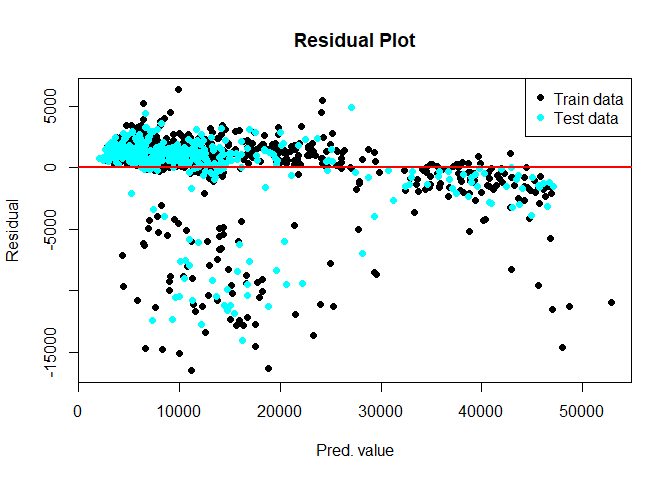

```r
plot(forest_train_pred, forest_train_pred-ins_train$charges, col='black', pch=16, cex=1, main="Residual Plot", xlab="Pred. value", ylab="Residual")

points(forest_test_pred, forest_test_pred-ins_test$charges, col="cyan", pch=16, cex=1)

legend("topright", legend=c("Train data", "Test data"), col=c("black", "cyan"), pch=16, cex=1, bg="white")

abline(h=0, col="red", lwd=2)
```